# Austin House Price Prediction Using an XGBoost Model

Benard Omido

2024-07-01

```r
library(tidyverse)
library(tidymodels)
```

```r
austin <- read_csv("austinHousingData.csv")
austin
```

```
## # A tibble: 15,171 × 45
##          zpid city      streetAddress zipcode latitude longitude propertyTaxRate
##         <dbl> <chr>     <chr>           <dbl>    <dbl>     <dbl>           <dbl>
##  1  111373431 pflugerv… 14424 Lake V…   78660     30.4     -97.7            1.98
##  2  120900430 pflugerv… 1104 Strickl…   78660     30.4     -97.7            1.98
##  3 2084491383 pflugerv… 1408 Fort De…   78660     30.4     -97.6            1.98
##  4  120901374 pflugerv… 1025 Strickl…   78660     30.4     -97.7            1.98
##  5   60134862 pflugerv… 15005 Donna …   78660     30.4     -97.7            1.98
##  6 2080105342 pflugerv… 14908 Spring…   78660     30.4     -97.7            1.98
##  7  241932337 pflugerv… 14009 Cantat…   78660     30.4     -97.6            1.98
##  8   60134835 pflugerv… 15009 Drusil…   78660     30.4     -97.7            1.98
##  9   60134833 pflugerv… 1104 Traci M…   78660     30.4     -97.7            1.98
## 10   83827468 del valle 6808 Plains …   78617     30.2     -97.6            1.98
## # ℹ 15,161 more rows
## # ℹ 38 more variables: garageSpaces <dbl>, hasAssociation <lgl>,
## #   hasCooling <lgl>, hasGarage <lgl>, hasHeating <lgl>, hasSpa <lgl>,
## #   hasView <lgl>, homeType <chr>, parkingSpaces <dbl>, yearBuilt <dbl>,
## #   latestPrice <dbl>, numPriceChanges <dbl>, latest_saledate <chr>,
## #   latest_salemonth <dbl>, latest_saleyear <dbl>, latestPriceSource <chr>,
## #   numOfPhotos <dbl>, numOfAccessibilityFeatures <dbl>, …
```

```r
glimpse(austin)
```

```
## Rows: 15,171
## Columns: 45
## $ zpid                       <dbl> 111373431, 120900430, 2084491383, 120901374…
## $ city                       <chr> "pflugerville", "pflugerville", "pflugervil…
## $ streetAddress              <chr> "14424 Lake Victor Dr", "1104 Strickling Dr…
## $ zipcode                    <dbl> 78660, 78660, 78660, 78660, 78660, 78660, 7…
## $ latitude                   <dbl> 30.43063, 30.43267, 30.40975, 30.43211, 30.…
## $ longitude                  <dbl> -97.66308, -97.66170, -97.63977, -97.66166,…
## $ propertyTaxRate            <dbl> 1.98, 1.98, 1.98, 1.98, 1.98, 1.98, 1.98, 1…
## $ garageSpaces               <dbl> 2, 2, 0, 2, 0, 2, 0, 0, 0, 2, 2, 0, 2, 0, 2…
## $ hasAssociation             <lgl> TRUE, TRUE, TRUE, TRUE, TRUE, TRUE, TRUE, T…
## $ hasCooling                 <lgl> TRUE, TRUE, TRUE, TRUE, TRUE, TRUE, FALSE, …
## $ hasGarage                  <lgl> TRUE, TRUE, FALSE, TRUE, FALSE, TRUE, FALSE…
## $ hasHeating                 <lgl> TRUE, TRUE, TRUE, TRUE, TRUE, TRUE, FALSE, …
## $ hasSpa                     <lgl> FALSE, FALSE, FALSE, FALSE, FALSE, FALSE, F…
```

[output cut: 32 more lines]

**Explore the data**

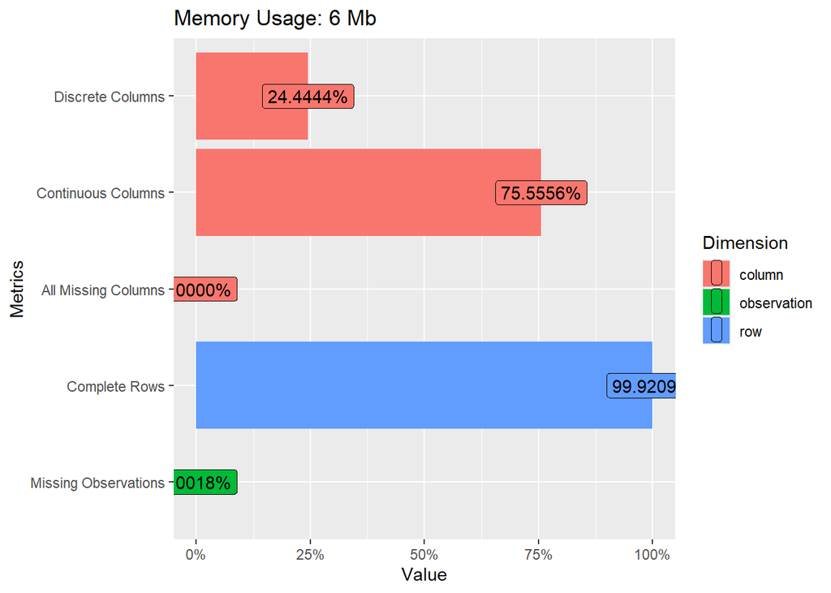

```r
library(DataExplorer)

plot_intro(austin)
```

```r
# There are a few missing rows in the data
```

[output not shown]

**Drop columns that won’t be used in the analysis**

```r
# Garage spaces is removed because it is a duplicate of the parking space column

austin_df <- austin %>%
  select(-c(latestPriceSource, latest_saleyear,
            latest_salemonth, latest_saledate, numPriceChanges, garageSpaces,                      streetAddress, city)) %>%
  mutate_if(is.character, factor) %>%
  mutate_if(is.logical, factor)

austin_df
```

```
## # A tibble: 15,171 × 37
##        zpid zipcode latitude longitude propertyTaxRate hasAssociation hasCooling
##       <dbl>   <dbl>    <dbl>     <dbl>           <dbl> <fct>          <fct>
##  1   1.11e8   78660     30.4     -97.7            1.98 TRUE           TRUE
##  2   1.21e8   78660     30.4     -97.7            1.98 TRUE           TRUE
##  3   2.08e9   78660     30.4     -97.6            1.98 TRUE           TRUE
##  4   1.21e8   78660     30.4     -97.7            1.98 TRUE           TRUE
##  5   6.01e7   78660     30.4     -97.7            1.98 TRUE           TRUE
##  6   2.08e9   78660     30.4     -97.7            1.98 TRUE           TRUE
##  7   2.42e8   78660     30.4     -97.6            1.98 TRUE           FALSE
##  8   6.01e7   78660     30.4     -97.7            1.98 TRUE           TRUE
##  9   6.01e7   78660     30.4     -97.7            1.98 TRUE           TRUE
## 10   8.38e7   78617     30.2     -97.6            1.98 TRUE           TRUE
## # ℹ 15,161 more rows
## # ℹ 30 more variables: hasGarage <fct>, hasHeating <fct>, hasSpa <fct>,
## #   hasView <fct>, homeType <fct>, parkingSpaces <dbl>, yearBuilt <dbl>,
## #   latestPrice <dbl>, numOfPhotos <dbl>, numOfAccessibilityFeatures <dbl>,
## #   numOfAppliances <dbl>, numOfParkingFeatures <dbl>,
## #   numOfPatioAndPorchFeatures <dbl>, numOfSecurityFeatures <dbl>,
## #   numOfWaterfrontFeatures <dbl>, numOfWindowFeatures <dbl>, …
```

**Average House prices by the zip code**

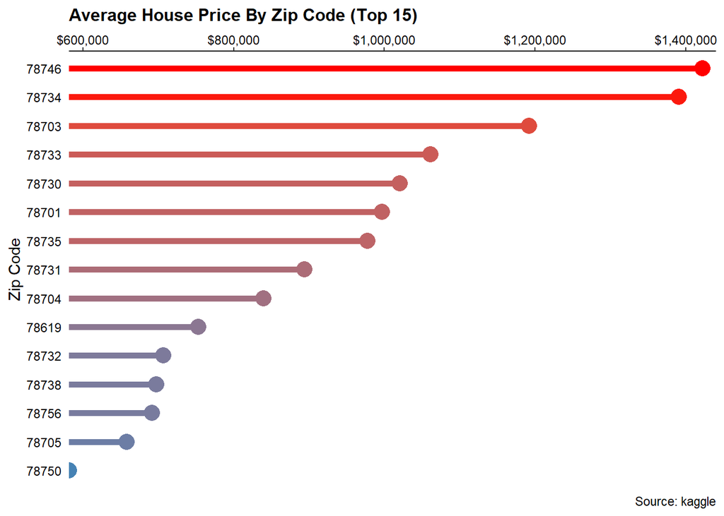

```r
austin_df %>%
  group_by(zipcode) %>%
  summarize(avg_price = mean(latestPrice)) %>%
  slice_max(avg_price, n = 15) %>%
  mutate(zipcode = as.factor(zipcode)) %>%
  ggplot(aes(avg_price, fct_reorder(zipcode, avg_price),
             color = avg_price)) +
  geom_point(size = 5) +
  geom_segment(aes(xend = 581110, yend = zipcode), linewidth = 2) +
  scale_x_continuous(expand = c(0,0), limits = c(581110, 1440000),
                     position = "top", labels = scales::dollar) +
  scale_color_gradient(low = "steelblue", high = "red") +
  labs(y = "Zip Code",
       x = NULL,
       title = "Average House Price By Zip Code (Top 15)",
       caption = "Source: kaggle") +
  theme_classic() +
  theme(axis.line.y = element_blank(),
        axis.ticks.y = element_blank(),
        axis.text = element_text(color = "black"),
        plot.title = element_text(size = 12, color = "black", face = "bold"),
        legend.position = "none")
```

**Distribution of house prices in Austin**

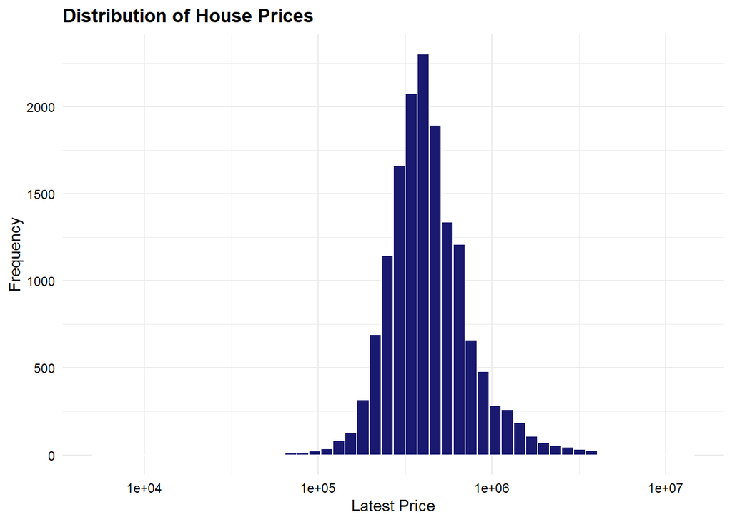

```r
austin_df %>%
  ggplot(aes(latestPrice)) +
  geom_histogram(bins = 50, fill = "midnightblue", color = "white") +
  scale_x_log10() +
  labs(x = "Latest Price", y = "Frequency", title = "Distribution of House Prices") +
  theme_minimal()+
  theme(axis.text = element_text(color = "black"),
        plot.title = element_text(colour = "black", face = "bold"))
```

```r
# The house prices are right skewed, with a few large values, thus the need to use log   to transform the x axis. (Spreads out the small values and compresses the large ones)
```

**Distribution of House Price By location (latitude & longitude)**

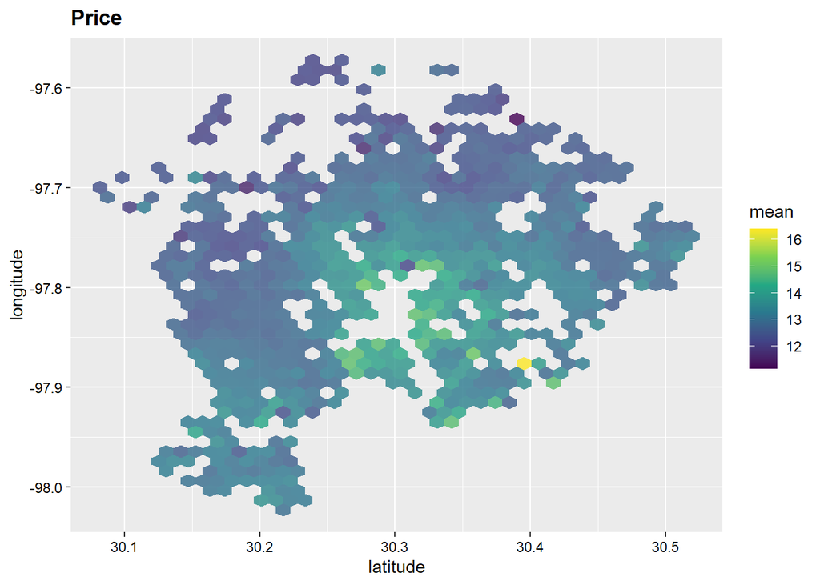

```r
price_plot <- austin_df %>%
  ggplot(aes(latitude, longitude, z = log(latestPrice))) +
  stat_summary_hex(alpha = 0.8, bins = 40) +
  scale_fill_viridis_c() +
  labs(fill = "mean", title = "Price") +
  theme(axis.text = element_text(color = "black"),
        plot.title = element_text(colour = "black", face = "bold"))

price_plot
```

The central areas of Austin show higher mean log-transformed house prices, as indicated by brighter colors on the map.

Areas farther from the city center exhibit lower mean log-transformed house prices, shown by darker colors.

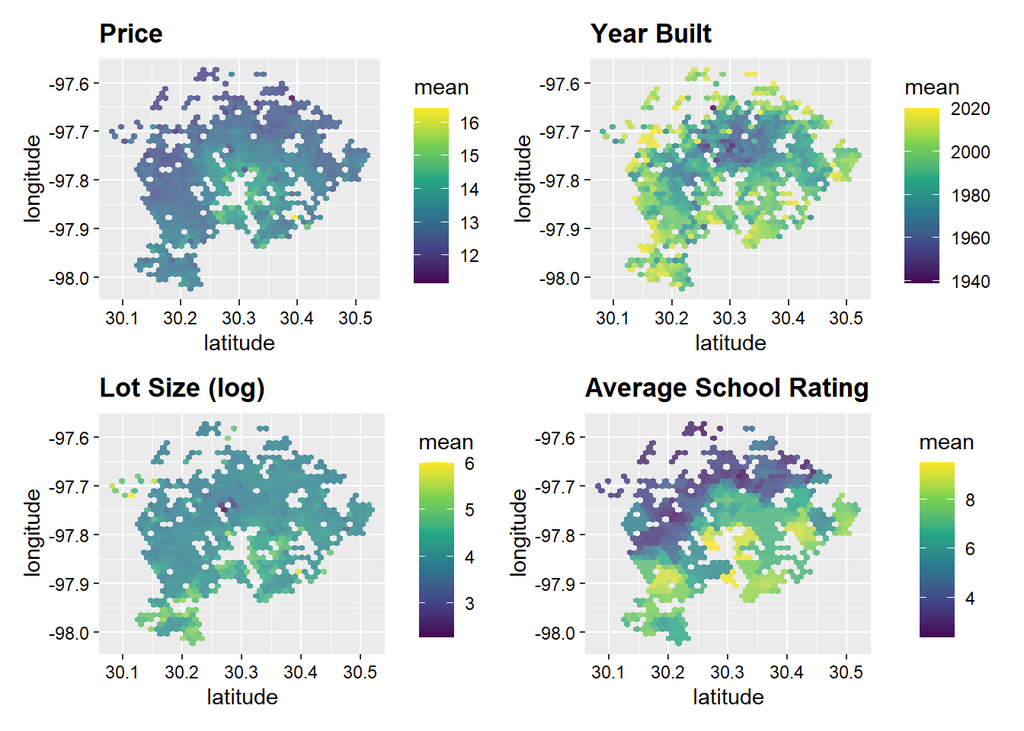

```r
# Distribution of House prices, year Built, lot Size, and average school ratings
library(patchwork)

austin_plot <- function(var, title){
  austin_df %>%
  ggplot(aes(latitude, longitude, z = {{var}})) +
    stat_summary_hex(alpha = 0.8, bins = 40) +
    scale_fill_viridis_c() +
    labs(fill = "mean", title = title) +
    theme(axis.text = element_text(color = "black"),
          plot.title = element_text(colour = "black", face = "bold"))
}

(price_plot + austin_plot(yearBuilt, "Year Built")) /
  (austin_plot(log10(lotSizeSqFt), "Lot Size (log)") + austin_plot(avgSchoolRating, "Average School Rating"))
```

Majority of the recent houses and those with large lot sizes are farther away from the center of the city

### **Build the model**

```r
austin_df <- austin_df %>%
  mutate(latestPrice = log10(latestPrice))

# Create training and test data sets

set.seed(123)

austin_splits <- initial_split(austin_df)

austin_train <- training(austin_splits)
austin_train
```

```
## # A tibble: 11,378 × 37
##        zpid zipcode latitude longitude propertyTaxRate hasAssociation hasCooling
##       <dbl>   <dbl>    <dbl>     <dbl>           <dbl> <fct>          <fct>
##  1 29343635   78733     30.3     -97.9            1.98 FALSE          TRUE
##  2 29334609   78735     30.3     -97.9            1.98 TRUE           TRUE
##  3 64576087   78744     30.2     -97.7            1.98 TRUE           TRUE
##  4 29371625   78759     30.4     -97.8            1.98 FALSE          TRUE
##  5 29507487   78749     30.2     -97.9            1.98 TRUE           TRUE
##  6 29470113   78747     30.2     -97.7            1.98 TRUE           TRUE
##  7 29363061   78759     30.4     -97.8            1.98 FALSE          TRUE
##  8 29460279   78704     30.2     -97.8            1.98 TRUE           TRUE
##  9 29431396   78758     30.4     -97.7            1.98 FALSE          TRUE
## 10 29496909   78749     30.2     -97.9            1.98 TRUE           TRUE
## # ℹ 11,368 more rows
## # ℹ 30 more variables: hasGarage <fct>, hasHeating <fct>, hasSpa <fct>,
## #   hasView <fct>, homeType <fct>, parkingSpaces <dbl>, yearBuilt <dbl>,
## #   latestPrice <dbl>, numOfPhotos <dbl>, numOfAccessibilityFeatures <dbl>,
## #   numOfAppliances <dbl>, numOfParkingFeatures <dbl>,
## #   numOfPatioAndPorchFeatures <dbl>, numOfSecurityFeatures <dbl>,
## #   numOfWaterfrontFeatures <dbl>, numOfWindowFeatures <dbl>, …
```

```r
austin_test <- testing(austin_splits)
austin_test
```

```
## # A tibble: 3,793 × 37
##        zpid zipcode latitude longitude propertyTaxRate hasAssociation hasCooling
##       <dbl>   <dbl>    <dbl>     <dbl>           <dbl> <fct>          <fct>
##  1   2.08e9   78660     30.4     -97.6            1.98 TRUE           TRUE
##  2   6.01e7   78660     30.4     -97.7            1.98 TRUE           TRUE
##  3   8.80e7   78717     30.5     -97.8            2.21 TRUE           TRUE
##  4   1.22e8   78717     30.5     -97.8            2.21 TRUE           TRUE
##  5   8.38e7   78747     30.1     -97.7            1.98 FALSE          TRUE
##  6   7.04e7   78725     30.2     -97.6            1.98 TRUE           TRUE
##  7   7.03e7   78726     30.4     -97.9            1.98 TRUE           TRUE
##  8   8.38e7   78747     30.1     -97.7            1.98 FALSE          FALSE
##  9   7.03e7   78726     30.4     -97.9            1.98 TRUE           TRUE
## 10   2.95e7   78725     30.2     -97.6            1.98 TRUE           TRUE
## # ℹ 3,783 more rows
## # ℹ 30 more variables: hasGarage <fct>, hasHeating <fct>, hasSpa <fct>,
## #   hasView <fct>, homeType <fct>, parkingSpaces <dbl>, yearBuilt <dbl>,
## #   latestPrice <dbl>, numOfPhotos <dbl>, numOfAccessibilityFeatures <dbl>,
## #   numOfAppliances <dbl>, numOfParkingFeatures <dbl>,
## #   numOfPatioAndPorchFeatures <dbl>, numOfSecurityFeatures <dbl>,
## #   numOfWaterfrontFeatures <dbl>, numOfWindowFeatures <dbl>, …
```

```r
# Create cross validation folds

set.seed(234)

austin_folds <- vfold_cv(austin_train, v = 10)
austin_folds
```

```
## #  10-fold cross-validation
## # A tibble: 10 × 2
##    splits               id
##    <list>               <chr>
##  1 <split [10240/1138]> Fold01
##  2 <split [10240/1138]> Fold02
##  3 <split [10240/1138]> Fold03
##  4 <split [10240/1138]> Fold04
##  5 <split [10240/1138]> Fold05
##  6 <split [10240/1138]> Fold06
##  7 <split [10240/1138]> Fold07
##  8 <split [10240/1138]> Fold08
##  9 <split [10241/1137]> Fold09
## 10 <split [10241/1137]> Fold10
```

**Create a recipe**

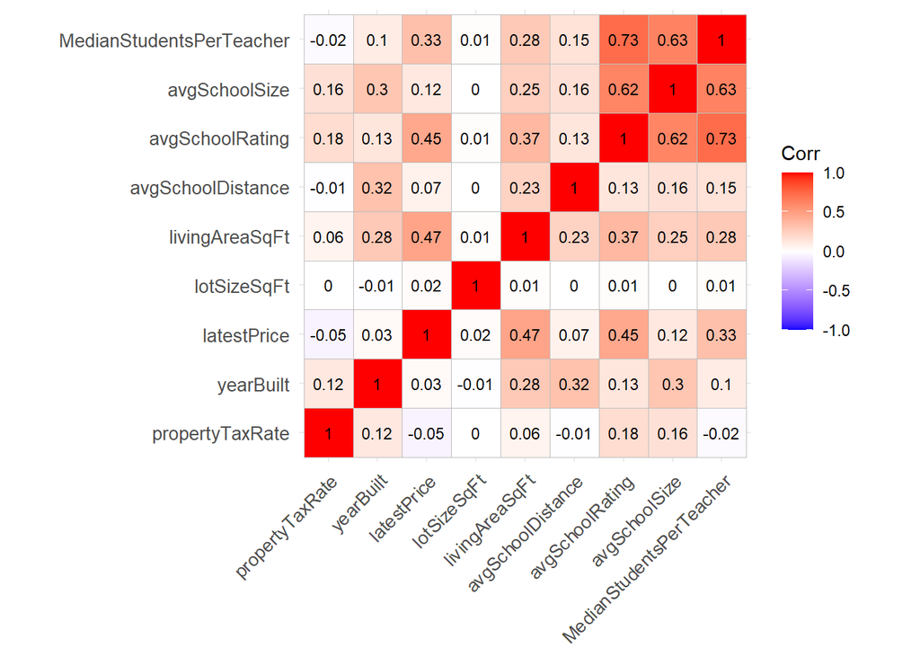

```r
# First check for correlation

numeric_vars <- austin_df %>%
  select(where(is.numeric), -c(zpid, zipcode, latitude, longitude,
                               parkingSpaces, starts_with("num")))

cor_matrix <- cor(numeric_vars, use = "complete.obs")

library(ggcorrplot)

ggcorrplot(cor_matrix, method = "square",
           type = "full",
           lab = TRUE,
           lab_size = 3,
           tl.cex = 10)
```

There are no highly correlated values in the data. Highest correlation = 0.73, which is between median students per teacher and average school rating

```r
austin_rec <- recipe(latestPrice ~ ., data = austin_train) %>%
  update_role(zpid, new_role = "ID") %>%
  update_role(zipcode, new_role = "zip") %>%
  step_rm(hasAssociation, hasCooling, hasHeating, hasView, hasGarage,
          numOfPhotos, numOfAccessibilityFeatures, numOfAppliances,
          numOfPatioAndPorchFeatures, numOfSecurityFeatures, numOfWaterfrontFeatures,
          numOfWindowFeatures, numOfCommunityFeatures, numOfPrimarySchools, numOfElementarySchools,
          numOfMiddleSchools, numOfHighSchools, numOfStories, avgSchoolSize, avgSchoolDistance) %>%

#This columns are removed because they don't add significant value to the model

  step_other(homeType, threshold = 0.01) %>%
  step_log(lotSizeSqFt, base = 10) %>%
  #step_ns(latitude, longitude, deg_free = 30) %>%
  step_dummy(all_nominal_predictors()) %>%
  step_nzv(all_predictors())

austin_rec
```

```r
austin_prep <- prep(austin_rec)
austin_prep

bake(austin_prep, new_data = NULL)
```

```
## # A tibble: 11,378 × 17
##        zpid zipcode latitude longitude propertyTaxRate parkingSpaces yearBuilt
##       <dbl>   <dbl>    <dbl>     <dbl>           <dbl>         <dbl>     <dbl>
##  1 29343635   78733     30.3     -97.9            1.98             3      1994
##  2 29334609   78735     30.3     -97.9            1.98             2      2001
##  3 64576087   78744     30.2     -97.7            1.98             0      2003
##  4 29371625   78759     30.4     -97.8            1.98             6      1976
##  5 29507487   78749     30.2     -97.9            1.98             2      1991
##  6 29470113   78747     30.2     -97.7            1.98             0      1996
##  7 29363061   78759     30.4     -97.8            1.98             4      1979
##  8 29460279   78704     30.2     -97.8            1.98             0      1981
##  9 29431396   78758     30.4     -97.7            1.98             2      1973
## 10 29496909   78749     30.2     -97.9            1.98             0      2001
## # ℹ 11,368 more rows
## # ℹ 10 more variables: numOfParkingFeatures <dbl>, lotSizeSqFt <dbl>,
## #   livingAreaSqFt <dbl>, avgSchoolRating <dbl>,
## #   MedianStudentsPerTeacher <dbl>, numOfBathrooms <dbl>, numOfBedrooms <dbl>,
## #   latestPrice <dbl>, hasSpa_TRUE. <dbl>, homeType_Single.Family <dbl>
```

Build an XGBoost model

```r
xgb_spec <-
  boost_tree(trees = 1000,
             tree_depth = tune(),
             min_n = tune(),
             mtry = tune(),
             sample_size = tune(),
             learn_rate = tune(),
             loss_reduction = tune()
             ) %>%
  set_engine("xgboost") %>%
  set_mode("regression")

xgb_spec
```

```
## Boosted Tree Model Specification (regression)
##
## Main Arguments:
##   mtry = tune()
##   trees = 1000
##   min_n = tune()
##   tree_depth = tune()
##   learn_rate = tune()
##   loss_reduction = tune()
##   sample_size = tune()
##
## Computational engine: xgboost
```

Create a workflow

```r
xgb_wf <- workflow() %>%
  add_recipe(austin_rec) %>%
  add_model(xgb_spec)

xgb_wf
```

```
## ══ Workflow ════════════════════════════════════════════════════════════════════
## Preprocessor: Recipe
## Model: boost_tree()
##
## ── Preprocessor ────────────────────────────────────────────────────────────────
## 5 Recipe Steps
##
## • step_rm()
## • step_other()
## • step_log()
## • step_dummy()
## • step_nzv()
##
## ── Model ───────────────────────────────────────────────────────────────────────
## Boosted Tree Model Specification (regression)
##
## Main Arguments:
##   mtry = tune()
##   trees = 1000
##   min_n = tune()
##   tree_depth = tune()
##   learn_rate = tune()
##   loss_reduction = tune()
##   sample_size = tune()
##
## Computational engine: xgboost
```

Create a grid

```r
set.seed(567)

xgb_grid <- grid_max_entropy(
  tree_depth(range = c(5L, 15L)),
  min_n(range = c(10L, 30L)),
  mtry(range = c(5L, 60L)),
  sample_size = sample_prop(range = c(0.5, 1.0)),
  learn_rate(range = c(-2,-1 )),
  loss_reduction(range = c(-10, -5)),
  size = 20
)

xgb_grid
```

```
## # A tibble: 20 × 6
##    tree_depth min_n  mtry sample_size learn_rate loss_reduction
##         <int> <int> <int>       <dbl>      <dbl>          <dbl>
##  1         14    21     9       0.583     0.0544       2.30e-10
##  2          6    10    10       0.866     0.0407       1.69e- 8
##  3         11    28    45       0.686     0.0233       2.04e- 8
##  4         12    12    42       0.594     0.0210       5.95e- 7
##  5         11    13    13       0.885     0.0846       1.62e-10
##  6          8    29    41       0.721     0.0148       1.87e-10
##  7         14    26    13       0.862     0.0198       1.97e- 6
##  8         15    24     7       0.892     0.0283       1.05e-10
##  9         11    21    21       0.530     0.0170       1.73e- 8
## 10         12    13    36       0.878     0.0556       4.84e- 8
## 11         14    25    35       0.622     0.0209       4.49e- 7
## 12          6    25    56       0.567     0.0467       5.18e-10
## 13          8    16    56       0.667     0.0842       9.12e- 8
## 14         12    14    50       0.671     0.0910       1.62e-10
## 15          7    21     8       0.502     0.0248       2.13e- 6
## 16         10    17    14       0.958     0.0157       4.54e- 9
## 17          6    10    26       0.812     0.0229       7.16e- 7
## 18          8    26    44       0.547     0.0532       1.41e- 6
## 19         10    18     8       0.691     0.0126       5.73e- 7
## 20         14    23    26       0.811     0.0838       2.29e- 6
```

```r
# We use the finetune package because it has racing methods, which throw away combinations of above parameters that do not turn out well

library(finetune)
```

```r
set.seed(678)
doParallel::registerDoParallel()

library(xgboost)

xgb_rs <-
  tune_race_anova(xgb_wf,
                  austin_folds,
                  grid = xgb_grid,
                  metrics = metric_set(rmse, rsq, mae),
                  control = control_race(verbose_elim = TRUE))   # Tells us what have been eliminated

xgb_rs
```

```
## # Tuning results
## # 10-fold cross-validation
## # A tibble: 10 × 5
##    splits               id     .order .metrics           .notes
##    <list>               <chr>   <int> <list>             <list>
##  1 <split [10240/1138]> Fold01      3 <tibble [60 × 10]> <tibble [0 × 3]>
##  2 <split [10240/1138]> Fold07      2 <tibble [60 × 10]> <tibble [0 × 3]>
##  3 <split [10241/1137]> Fold09      1 <tibble [60 × 10]> <tibble [0 × 3]>
##  4 <split [10240/1138]> Fold08      4 <tibble [30 × 10]> <tibble [0 × 3]>
##  5 <split [10241/1137]> Fold10      5 <tibble [15 × 10]> <tibble [0 × 3]>
##  6 <split [10240/1138]> Fold04      6 <tibble [12 × 10]> <tibble [0 × 3]>
##  7 <split [10240/1138]> Fold02      7 <tibble [9 × 10]>  <tibble [0 × 3]>
##  8 <split [10240/1138]> Fold05      8 <tibble [6 × 10]>  <tibble [0 × 3]>
##  9 <split [10240/1138]> Fold06      9 <tibble [6 × 10]>  <tibble [0 × 3]>
## 10 <split [10240/1138]> Fold03     10 <tibble [6 × 10]>  <tibble [0 × 3]>
```

- tune_race_anova - is an advanced hyperparameter tuning method that uses racing methods and ANOVA to eliminate poor-performing hyperparameter configurations early, thus focusing computational resources on the most promising configurations.
- tune_grid - performs hyperparameter tuning by evaluating all combinations of hyperparameters in a predefined grid. This method is straightforward but can be computationally expensive, especially if the grid is large.

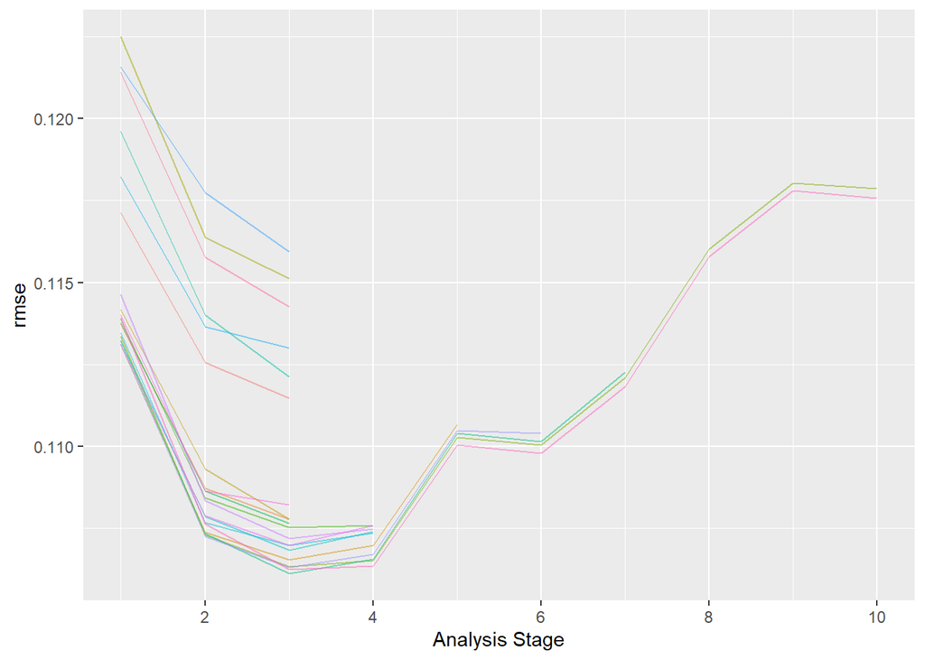

```r
plot_race(xgb_rs)
```

The sets of parameters that do not perform well are removed earlier. Only the last two models run to completion

```r
xgb_rs %>% collect_metrics()
```

```
## # A tibble: 6 × 12
##    mtry min_n tree_depth learn_rate loss_reduction sample_size .metric
##   <int> <int>      <int>      <dbl>          <dbl>       <dbl> <chr>
## 1    41    29          8     0.0148       1.87e-10       0.721 mae
## 2    41    29          8     0.0148       1.87e-10       0.721 rmse
## 3    41    29          8     0.0148       1.87e-10       0.721 rsq
## 4     8    18         10     0.0126       5.73e- 7       0.691 mae
## 5     8    18         10     0.0126       5.73e- 7       0.691 rmse
## 6     8    18         10     0.0126       5.73e- 7       0.691 rsq
## # ℹ 5 more variables: .estimator <chr>, mean <dbl>, n <int>, std_err <dbl>,
## #   .config <chr>
```

```r
show_best(xgb_rs, metric = "rmse")
```

```
## # A tibble: 2 × 12
##    mtry min_n tree_depth learn_rate loss_reduction sample_size .metric
##   <int> <int>      <int>      <dbl>          <dbl>       <dbl> <chr>
## 1     8    18         10     0.0126       5.73e- 7       0.691 rmse
## 2    41    29          8     0.0148       1.87e-10       0.721 rmse
## # ℹ 5 more variables: .estimator <chr>, mean <dbl>, n <int>, std_err <dbl>,
## #   .config <chr>
```

- An RMSE of 0.1180378 indicates that, on average, the predictions differ from the actual log-transformed prices by about 0.118.
- MAE measures the average absolute difference between predicted and actual values. An MAE of 0.07135576 means that, on average, the absolute error in the log-transformed prices is 0.071.
- An R² of 0.74673270 indicates that approximately 74.67% of the variance in the log-transformed prices is explained by the model.

```r
# Finalize the model

xgb_final <- xgb_wf %>%
  finalize_workflow(select_best(xgb_rs, metric = "rmse"))

xgb_final
```

```
## ══ Workflow ════════════════════════════════════════════════════════════════════
## Preprocessor: Recipe
## Model: boost_tree()
##
## ── Preprocessor ────────────────────────────────────────────────────────────────
## 5 Recipe Steps
##
## • step_rm()
## • step_other()
## • step_log()
## • step_dummy()
## • step_nzv()
##
## ── Model ───────────────────────────────────────────────────────────────────────
## Boosted Tree Model Specification (regression)
##
## Main Arguments:
##   mtry = 8
##   trees = 1000
##   min_n = 18
##   tree_depth = 10
##   learn_rate = 0.0126344511884109
##   loss_reduction = 5.7296344844774e-07
##   sample_size = 0.691341654164717
##
## Computational engine: xgboost
```

```r
# Fit final model on the splits

austin_fit <- last_fit(xgb_final, austin_splits)

austin_fit
```

```
## # Resampling results
## # Manual resampling
## # A tibble: 1 × 6
##   splits               id              .metrics .notes   .predictions .workflow
##   <list>               <chr>           <list>   <list>   <list>       <list>
## 1 <split [11378/3793]> train/test spl… <tibble> <tibble> <tibble>     <workflow>
```

```r
austin_fit %>% collect_metrics()
```

```
## # A tibble: 2 × 4
##   .metric .estimator .estimate .config
##   <chr>   <chr>          <dbl> <chr>
## 1 rmse    standard       0.135 Preprocessor1_Model1
## 2 rsq     standard       0.702 Preprocessor1_Model1
```

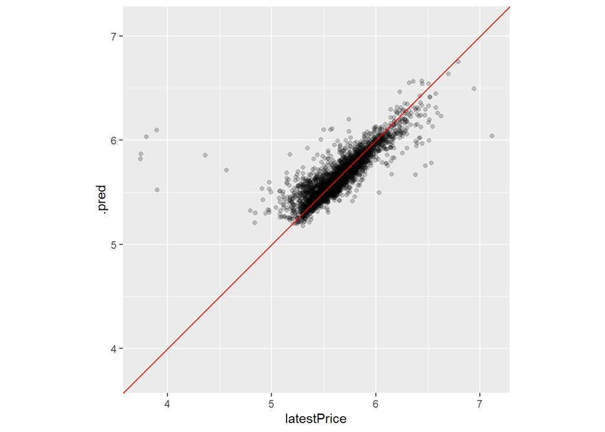

```r
# Collect predictions

austin_fit %>%
  collect_predictions() %>%
  ggplot(aes(latestPrice, .pred)) +
  geom_point(alpha = 0.2) +
  geom_abline(color = "red") +
  coord_obs_pred()
```

There are a few over predicted values in the above plot

```r
over_preds <- austin_fit %>%
  collect_predictions() %>%
  mutate(residuals = latestPrice - .pred) %>%
  arrange(desc(abs(residuals))) %>%
  slice_head( n = 10)

over_preds
```

```
## # A tibble: 10 × 6
##    .pred id                .row latestPrice .config              residuals
##    <dbl> <chr>            <int>       <dbl> <chr>                    <dbl>
##  1  6.03 train/test split 13185        3.80 Preprocessor1_Model1    -2.23
##  2  6.10 train/test split 14581        3.90 Preprocessor1_Model1    -2.20
##  3  5.87 train/test split  5797        3.75 Preprocessor1_Model1    -2.12
##  4  5.82 train/test split   845        3.74 Preprocessor1_Model1    -2.08
##  5  5.52 train/test split  9870        3.90 Preprocessor1_Model1    -1.62
##  6  5.85 train/test split 14781        4.36 Preprocessor1_Model1    -1.49
##  7  5.71 train/test split 14699        4.57 Preprocessor1_Model1    -1.14
##  8  6.04 train/test split 14276        7.11 Preprocessor1_Model1     1.08
##  9  5.78 train/test split  1418        6.53 Preprocessor1_Model1     0.749
## 10  5.75 train/test split  1523        6.48 Preprocessor1_Model1     0.721
```

```r
austin %>%
  filter(row_number() %in% over_preds$.row) %>%
  select(zipcode, latitude, longitude, yearBuilt, parkingSpaces, latestPrice)
```

```
## # A tibble: 10 × 6
##    zipcode latitude longitude yearBuilt parkingSpaces latestPrice
##      <dbl>    <dbl>     <dbl>     <dbl>         <dbl>       <dbl>
##  1   78732     30.4     -97.9      2000             4        5500
##  2   78746     30.3     -97.8      1965             2     3395000
##  3   78733     30.3     -97.9      2003             1     2995000
##  4   78732     30.4     -97.9      2006             3        5600
##  5   78721     30.3     -97.7      2007             1        8000
##  6   78703     30.3     -97.8      1932             0        6300
##  7   78731     30.3     -97.8      2007             2    13000000
##  8   78746     30.3     -97.8      1993             2        7900
##  9   78705     30.3     -97.7      1940             1       37000
## 10   78705     30.3     -97.7      1940             2       23000
```

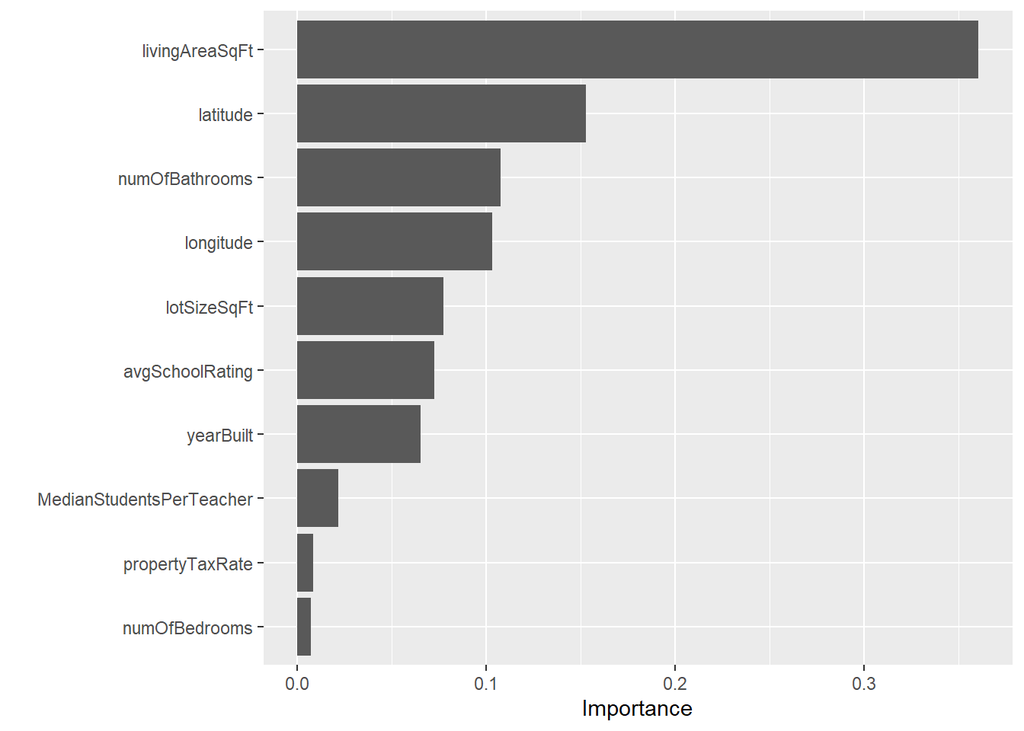

```r
# Check the variable importance

library(vip)

extract_workflow(austin_fit) %>%
  extract_fit_parsnip() %>%
  vip(num_features = 10, geom = "col")
```

```r
# Deploying the model
library(vetiver)

austin_deploy <- extract_workflow(austin_fit) %>%
  vetiver_model("austin_xgb")

austin_deploy
```

```
##
## ── austin_xgb ─ <bundled_workflow> model for deployment
## A xgboost regression modeling workflow using 34 features
```